# Project 2 - Video Game Analysis

Devin Teran

3/6/2020

## Overview

**Data Source:** https://www.kaggle.com/ashaheedq/video-games-sales-2019  
We’re going to analyze video game data from kaggle, which outlines game genre types, sales numbers, critic and user ratings, and more.

Note: there are some games that users did not rate potentially because those games aren’t for commercial use (e.g. genre ‘education’). We’re going to remove these games from our analysis.

## Clean Data

1. Import data from csv stored on GitHub
2. Subset data to include only columns we want to analyze
3. To narrow our analysis, we’ll remove games that do not have both a critic and user score and global sale value

```r
file_path <- "https://raw.githubusercontent.com/devinteran/Data607-Project2/master/vgsales-12-4-2019.csv"
video_game_raw <- read_csv(file_path)
#select subset of columns
video_game <- select(video_game_raw,Rank,basename,Genre,ESRB_Rating,Platform,Publisher,Critic_Score,User_Score,Total_Shipped,Global_Sales,NA_Sales,PAL_Sales,JP_Sales,Other_Sales,Year)

#Remove games where we are missing a critic score or user score
video_game <- filter(video_game,is.na(User_Score) == FALSE,is.na(Critic_Score) == FALSE,is.na(Global_Sales) == FALSE)
```

## Questions to Answer

- Which genre has the highest rating games by critics? by users?
- Do these high rating genres have the most global sales?
- Generally, do critics or user ratings reflect global game sales?

## Which genre has the highest ratings by critics and users?

Next let’s look if sales correlate with critic or users findings..

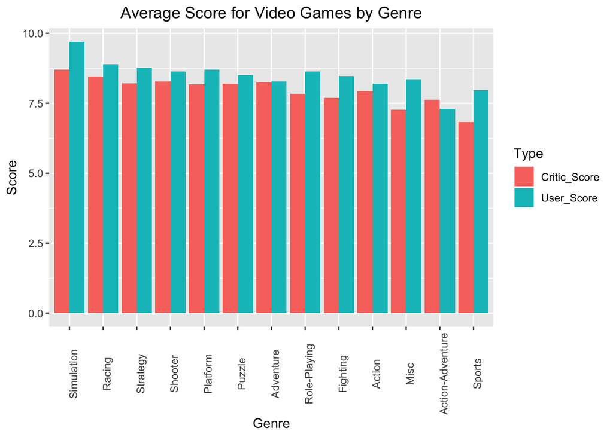

```r
genre_score<- video_game %>% group_by(Genre) %>% summarize(Critic_Score = mean(Critic_Score,na.rm=TRUE),User_Score = mean(User_Score,na.rm=TRUE))
genre_score <- pivot_longer(genre_score,cols=ends_with("Score"),names_to="Type",values_to="Score")

ggplot(genre_score,aes(fill=Type,reorder(x=Genre,-Score),y=Score)) +
  geom_bar(position="dodge",stat = "identity") +
  theme(axis.text.x = element_text(angle = 90)) +
  xlab("Genre") +
  ggtitle("Average Score for Video Games by Genre") +
  theme(plot.title = element_text(hjust = 0.5))
```

Here we see the highest selling game genres globally are Racing, Action & Shooter.  
* Racing games are both highly rated and high sellers

```r
game_sales <- video_game %>% group_by(Genre) %>% summarize(Global_Sales = mean(Global_Sales,na.rm=TRUE))
filter(video_game,Genre == 'Action')
```

```
## # A tibble: 36 x 15
##     Rank basename Genre ESRB_Rating Platform Publisher Critic_Score User_Score
##    <dbl> <chr>    <chr> <chr>       <chr>    <chr>            <dbl>      <dbl>
##  1    80 grand-t… Acti… M           PS3      Rockstar…         10          9
##  2   108 grand-t… Acti… M           XOne     Rockstar…          9          9
##  3   148 unchart… Acti… T           PS3      Sony Com…          9.3        6.3
##  4   152 unchart… Acti… T           PS3      Sony Com…          9.5        9.6
##  5   161 red-dea… Acti… M           X360     Rockstar…          9.5       10
##  6   177 metal-g… Acti… M           PS2      Konami             9.5        7
##  7   181 metal-g… Acti… M           PS3      Konami             9.3        9.8
##  8   203 assassi… Acti… M           X360     Ubisoft            8.2        8
##  9   244 residen… Acti… M           PS3      Capcom             8.6        8.8
## 10   262 unchart… Acti… T           PS3      Sony Com…          8.7        8.6
## # … with 26 more rows, and 7 more variables: Total_Shipped <dbl>,
## #   Global_Sales <dbl>, NA_Sales <dbl>, PAL_Sales <dbl>, JP_Sales <dbl>,
## #   Other_Sales <dbl>, Year <dbl>
```

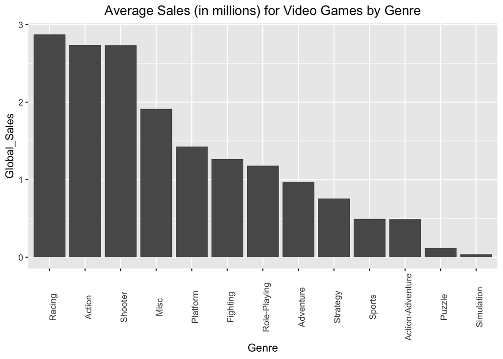

```r
ggplot(drop_na(game_sales),aes(reorder(x=Genre,-Global_Sales),y=Global_Sales)) +
  geom_bar(position="dodge",stat = "identity") +
  theme(axis.text.x = element_text(angle = 90)) +
  xlab("Genre") +
  ggtitle("Average Sales (in millions) for Video Games by Genre") +
  theme(plot.title = element_text(hjust = 0.5))
```

# Do Critic or User Ratings Predict Global Sales Better?

- Both critics and users rated Simulation games very highly and sales were almost 0.
- Critics and users rated Racing & Shooter games very high and these games sold a high volume of games
- Users did not rate Action games very high relative to other genres despite high sales

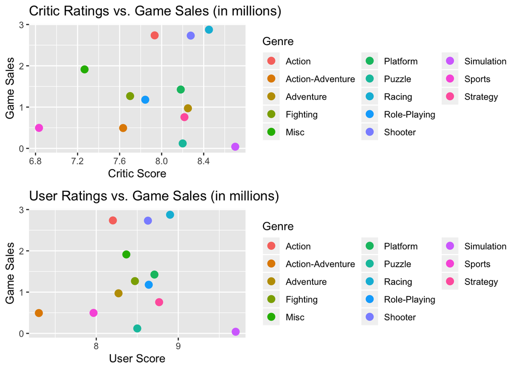

```r
genre_score<- video_game %>% group_by(Genre) %>% summarize(Critic_Score = mean(Critic_Score,na.rm=TRUE),User_Score = mean(User_Score,na.rm=TRUE))
genre_score <- pivot_longer(genre_score,cols=ends_with("Score"),names_to="Type",values_to="Score")
game_sales <- video_game %>% group_by(Genre) %>% summarize(Global_Sales = mean(Global_Sales,na.rm=TRUE))

sales_plus_scores <- genre_score %>% merge(game_sales,by="Genre")
sales_plus_scores_critic <- filter(drop_na(sales_plus_scores),Type == 'Critic_Score')
sales_plus_scores_user <- filter(drop_na(sales_plus_scores),Type == 'User_Score')

critic <- ggplot(sales_plus_scores_critic,aes(fill=Genre,x=Score,y=Global_Sales,color=Genre)) +
  geom_point(size=3) +
  xlab("Critic Score") +
  ylab("Game Sales") +
  ggtitle("Critic Ratings vs. Game Sales (in millions)") +
  guides(fill=guide_legend(ncol=3)) +
  geom_jitter()

user <- ggplot(sales_plus_scores_user,aes(fill=Genre,x=Score,y=Global_Sales,color=Genre)) +
  geom_point(size=3) +
  xlab("User Score") +
  ylab("Game Sales") +
  ggtitle("User Ratings vs. Game Sales (in millions)") +
  guides(fill=guide_legend(ncol=3)) +
  geom_jitter()
grid.arrange(critic,user)
```

# Conclusions

- Overall, users give games higher ratings than critics.
- Racing, Action and Shooter games are the best selling game genres.
- It’s very hard to tell whether users or critics ratings were more predictive of global sales. With more time and experience, I would like to use a more sophisticated model to predict which metric better predicts global sales.
- It would also be interesting to see the popularity of games in different regions using regional sales.